# Data Storage: Databases and R

Di Cook, Heike Hofmann  
2/10/2014

### What is a database?

- a collection of data
- a set of rules to manipulate data

Pros:

- efficient manipulation of large data
- convenient processing of data
- integration of multiple data sources
- access to a shared resource

### Example

- 2009 data expo: 12Gb of US airline traffic information
- Team of faculty and students analyzing the data
- Weather information at major airports stripped from various web sites and added as separate table, enable weather and air traffic operations to be compared
- Data converted from individual flights, to summaries calculated across different units: hours, day, month, year, airport, airline, …

Why a database?

- 12Gb is TOO BIG for R! (unless you have a main memory of >> 12Gb)
- Now, data on the order of some activities today, terabytes on a frequent basis are TOO BIG for databases! Then analysts revert back to FLAT FILES.

### Relational Databases

- data is collection of tables (in normal form)
- SQL (Structured Query Language) for manipulated, in particular, *querying* data
- DBMS (Database management system) for managing data

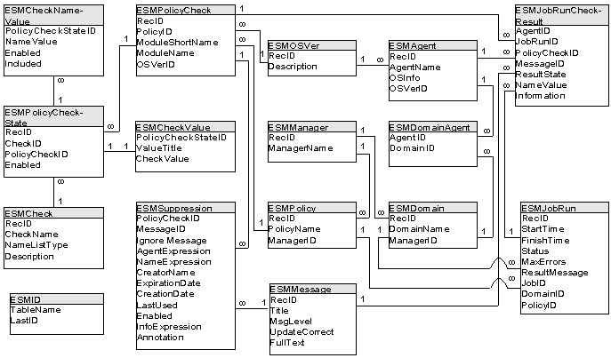

### Keys

Student

| *ID* | Name | Major |
| --- | --- | --- |
| 1234 | Never Ever | Math |
| 4321 | Some Times | CS |
| … | … | … |

*Keys* uniquely identify a record

Keys are used to link between tables: what are the names of the students not in class on Feb-09?

Attendance

| *ID* | *Date* | Status |
| --- | --- | --- |
| 1234 | 02-Feb | absent |
| 1234 | 09-Feb | absent |
| 4321 | 02-Feb | present |
| 4321 | 09-Feb | absent |

Relationships between tables: one-one, one-many, many-many

### Normal forms

DRY principle for data (Don't repeat yourself)

- more consistency, less redundancy
- harder to view and edit
- distinction between measured data and data indices (keys)

Normal forms: 1 - the key 2 - the whole key 3 - nothing but the key

### 1st normal form (the key)

- data is in rectangular form
- each row has a unique key
- order of rows, columns not important

| *ID* | Name | Major | *Date* | Status |
| --- | --- | --- | --- | --- |
| 1234 | Never Ever | Math | 02-Feb | absent |
| 1234 | Never Ever | Math | 09-Feb | absent |
| 4321 | Some Times | CS | 02-Feb | present |
| 4321 | Some Times | CS | 09-Feb | absent |

Counterindication for 1st normal form: e.g. duplicate rows, duplicate key entries

### 2nd normal form (the whole key)

a table in 1st NF is also in 2nd NF, if we need the *whole* key to describe any element in a row, i.e. no redundancy

Only ID needed for Name and Major - table below is *not* in 2nd normal form

| *ID* | Name | Major | *Date* | Status |
| --- | --- | --- | --- | --- |
| 1234 | Never Ever | Math | 02-Feb | absent |
| 1234 | Never Ever | Math | 09-Feb | absent |
| 4321 | Some Times | CS | 02-Feb | present |
| 4321 | Some Times | CS | 09-Feb | absent |

split table to get it into 2nd normal form

### 2nd normal form (the whole key)

Now the tables are in 1st NF and 2nd NF

Student

| *ID* | Name | Major |
| --- | --- | --- |
| 1234 | Never Ever | Math |
| 4321 | Some Times | CS |

Attendance

| *ID* | *Date* | Status |
| --- | --- | --- |
| 1234 | 02-Feb | absent |
| 1234 | 09-Feb | absent |
| 4321 | 02-Feb | present |
| 4321 | 09-Feb | absent |

Tables in 1st NF with a single key variable are automatically in 2nd NF

### 3rd normal form (nothing but the key)

- No non-key field contains information on another field
- Avoids update irregularities
- Zipcode determines city and state, but is not key field

[output not shown]

### Why normalize?

- Easier to maintain
- Reduce redundancy to detect possible errors
- Reduce overall data size
- Useful way of thinking about objects under study

### De-normalization

- So, now no redundancy, but unfortunately few statistical algorithms work with normalized data
- So have to de-normalize it - i.e. join data from different sources
- R: `merge` (base) or `join` (plyr)
- or directly in the database

### Structured Query Language

- Structured Query Language (1970, E Codds)
- Programming language used for accessing data in a database
- ANSI standard since 1986, ISO standard since 1987
- Still some portability issues between software systems!
- We’ll mainly focus on SQL queries to access data

### Syntax

- SQL is not case sensitive.
- Some systems require `;` at the end of each line. The semi-colon can be used to separate each SQL statement in a system that allows multiple command to be executed in a call to the server.

### Select

Student

| *ID* | Name | Major |
| --- | --- | --- |
| 1234 | Never Ever | Math |
| 4321 | Some Times | CS |

`Select * from student`

Attendance

| *ID* | *Date* | Status |
| --- | --- | --- |
| 1234 | 02-Feb | absent |
| 1234 | 09-Feb | absent |
| 4321 | 02-Feb | present |
| 4321 | 09-Feb | absent |

leads to

| *ID* | Name | Major |
| --- | --- | --- |
| 1234 | Never Ever | Math |
| 4321 | Some Times | CS |

### Where

Student

| *ID* | Name | Major |
| --- | --- | --- |
| 1234 | Never Ever | Math |
| 4321 | Some Times | CS |

`Select Name from student where Major='Math'`

Attendance

| *ID* | *Date* | Status |
| --- | --- | --- |
| 1234 | 02-Feb | absent |
| 1234 | 09-Feb | absent |
| 4321 | 02-Feb | present |
| 4321 | 09-Feb | absent |

leads to

| Name |
| --- |
| Never Ever |

### Aggregations

Student

| *ID* | Name | Major |
| --- | --- | --- |
| 1234 | Never Ever | Math |
| 4321 | Some Times | CS |

`Select ID, count(ID) from Attendance where Status='absent'`

Attendance

| *ID* | *Date* | Status |
| --- | --- | --- |
| 1234 | 02-Feb | absent |
| 1234 | 09-Feb | absent |
| 4321 | 02-Feb | present |
| 4321 | 09-Feb | absent |

leads to

| *ID* | Frequency |
| --- | --- |
| 1234 | 2 |
| 4321 | 1 |

### Additional Resources

- W3Schools: http://www.w3schools.com/sql/default.asp
- DBI package, RMySQL: http://cran.r-project.org/web/packages/RMySQL/RMySQL.pdf
- Getting ready for Wednesday's lab on your own machine?
  - Install mysql (from http://dev.mysql.com/downloads/). This is a stand-alone software that allows to connect to databases.
  - in R Install DBI and RMySQL - follow the instructions on http://biostat.mc.vanderbilt.edu/wiki/Main/RMySQL if things aren't working …
  - are you ready? try to run: `library(RMySQL)`